# Python Project - (Dataset Exploration Title)

## Univariate Exploration

> In this section, investigate distributions of individual variables. If you see unusual points or outliers, take a deeper look to clean things up and prepare yourself to look at relationships between variables.

> **Tip**: The project should have at least 10 visualizations distributed over univariate and bivariate plots to explore many relationships in the data set. Use reasoning to justify the flow of the exploration.

> **Tip**: Use the "Question-Visualization-Observations" framework throughout the exploration. This framework involves **asking a question from the data, creating a visualization to find answers, and then recording observations after each visualisation.**

### Borrower APR

For the first chart, we will examine the distribution of 'Borrower APR', using a histogram.

```python
from matplotlib import rcParams
```

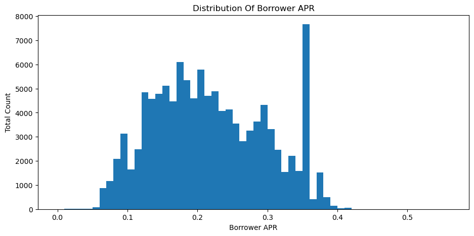

```python
rcParams['figure.figsize'] = 11, 5
bins = np.arange(0, subset.BorrowerAPR.max() + 0.05, 0.01)
plt.hist(data = subset, x = 'BorrowerAPR', bins = bins)
plt.xlabel('Borrower APR')
plt.ylabel('Total Count')
plt.title('Distribution Of Borrower APR')
plt.grid(False);
```

> **Tip**: Visualizations should depict the data appropriately so that the plots are easily interpretable. You should choose an appropriate plot type, data encodings, and formatting as needed. The formatting may include setting/adding the title, labels, legend, and comments. Also, do not overplot or incorrectly plot data.

```python
subset[subset.BorrowerAPR > 0.42]
```

|  | LoanStatus | BorrowerAPR | EmploymentStatus | StatedMonthlyIncome | IncomeVerifiable | DebtToIncomeRatio | LoanOriginalAmount | Term | ProsperRating (Alpha) |
| --- | --- | --- | --- | --- | --- | --- | --- | --- | --- |
| 18326 | Defaulted | 0.45857 | NaN | 10000.000000 | True | 0.10252 | 3000 | 36 | NaN |
| 22195 | Chargedoff | 0.46201 | NaN | 2916.666667 | True | 0.35430 | 1789 | 36 | NaN |
| 36018 | Completed | 0.51229 | NaN | 2838.000000 | True | 0.02852 | 1500 | 36 | NaN |
| 56761 | Defaulted | 0.50633 | NaN | 0.000000 | False | 0.03909 | 3000 | 36 | NaN |
| 82043 | Defaulted | 0.48873 | NaN | 1583.333333 | True | 0.10021 | 3000 | 36 | NaN |
| 103973 | Defaulted | 0.45857 | NaN | 3750.000000 | True | 0.19413 | 2800 | 36 | NaN |
| 105889 | Chargedoff | 0.42395 | Employed | 2250.000000 | True | 0.08000 | 1000 | 36 | HR |

#### Create a histogram to showcase the distribution of 'StatedMonthlyIncome'.

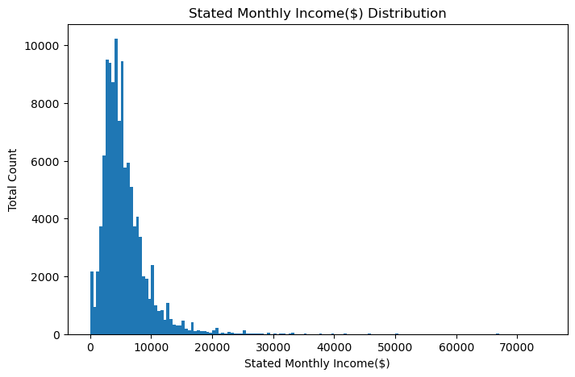

```python
rcParams['figure.figsize'] = 8, 5

income_bins = np.arange(0, 75000, 500)
plt.hist(data = subset, x='StatedMonthlyIncome', bins = income_bins);
plt.xlabel('Stated Monthly Income($)')
plt.ylabel('Total Count')
plt.title('Stated Monthly Income($) Distribution');
```

### we can see that the distribution of stated monthly income is right-skewed. Many of the loans are less than $30k.

```python
status_ordered = subset.LoanStatus.value_counts().sort_values(ascending = True)
```

```python
status_ordered
```

```
Cancelled                     5
Past Due (>120 days)         16
FinalPaymentInProgress      205
Past Due (16-30 days)       265
Past Due (91-120 days)      304
Past Due (61-90 days)       313
Past Due (31-60 days)       363
Past Due (1-15 days)        806
Defaulted                  5018
Chargedoff                11992
Completed                 38074
Current                   56576
Name: LoanStatus, dtype: int64
```

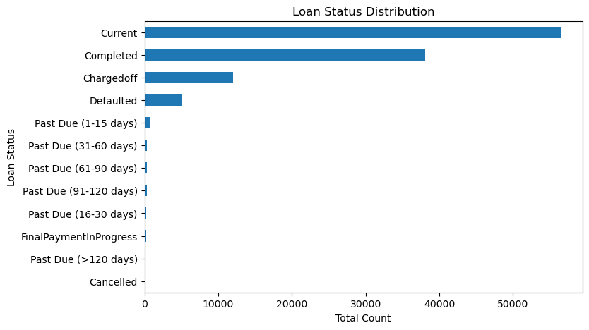

```python
rcParams['figure.figsize'] = 8, 5
status_ordered.plot(kind = 'barh', grid = False)
plt.ylabel('Loan Status')
plt.xlabel('Total Count')
plt.title('Loan Status Distribution');
```

### Of the features you investigated, were there any unusual distributions? Did you perform any operations on the data to tidy, adjust, or change the form of the data? If so, why did you do this?

Stated Monthly Income: The distribution of stated monthly income is right-skewed. Many of the loans are less than $30k, but there are some points that are much higher.

Loan Status: The vast majority of loans are marked as 'current', followed by 'Completed' and 'Charged off'. Even though there are alot more 'Defaulted' than all the 'Past Dues' put together, it seems like most people pay their loans on time.

## Bivariate Exploration

> In this section, investigate relationships between pairs of variables in your data. Make sure the variables that you cover here have been introduced in some fashion in the previous section (univariate exploration).

First let's look at the effect of other factors on Borrower's APR and BorrowerRate

```python
num_var = ['BorrowerAPR', 'StatedMonthlyIncome', 'LoanOriginalAmount', 'DebtToIncomeRatio']
cat_var = ['LoanStatus', 'IncomeVerifiable', 'EmploymentStatus', 'Term', 'ProsperRating (Alpha)']
```

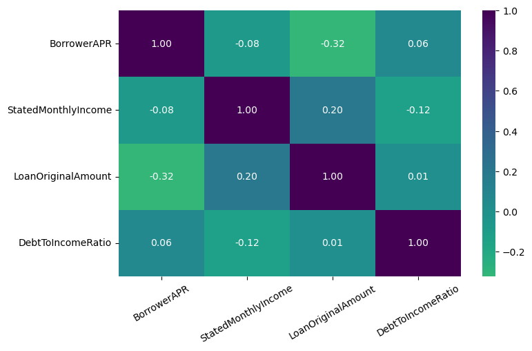

```python
sns.heatmap(subset[num_var].corr(), annot = True, fmt = '0.2f',
          cmap = 'viridis_r', center = 0)
plt.xticks(rotation = 30);
```

It seems like I was correct to expect that the borrower APR and the original loan amount were negatively correlated, meaning that the higher the loan, the lower the APR. From the heatmap, we can see that the correlation coefficient between the two variables is -0.32. The relationship between Debt-to-Income Ratio and Stated Monthly Income is also negatively correlated.Something else we can make out is that the correlation between the original loan amount and stated monthly income is 0.20, meaning that it's positively correlated. This makes sense since the higher the income, the higher the loan you should be able to acquire.

we will look at the relationship between each categorical variables.

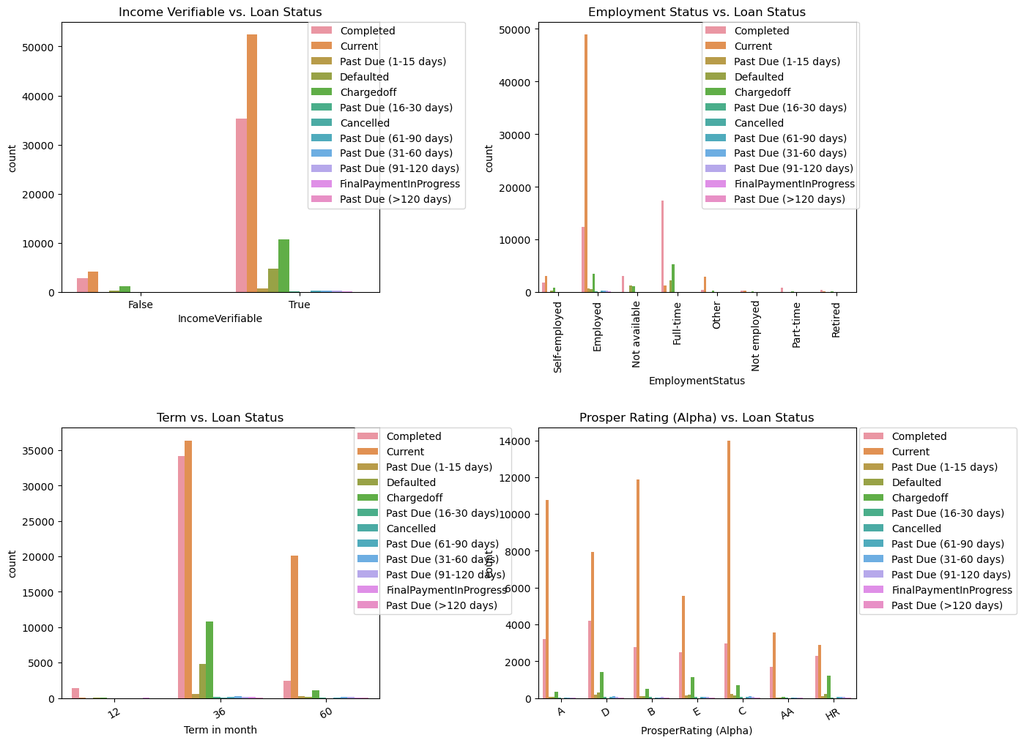

```python
rcParams['figure.figsize'] = 14, 12

#subplot 1
plt.subplot(2,2,1)
sns.countplot(data = subset, x = 'IncomeVerifiable', hue = 'LoanStatus')
plt.legend(bbox_to_anchor=(1.27, 1),
           borderaxespad=0) # push the legend to the side
plt.title('Income Verifiable vs. Loan Status');


#subplot 2
plt.subplot(2,2,2)
sns.countplot(data = subset, x = 'EmploymentStatus', hue = 'LoanStatus')
plt.xticks(rotation = 90)
plt.legend(bbox_to_anchor=(1.01, 1),
           borderaxespad=0)
plt.title('Employment Status vs. Loan Status');

#subplot 3
plt.subplot(2,2,3)
sns.countplot(data = subset, x = 'Term', hue = 'LoanStatus')
plt.xticks(rotation = 30)
plt.legend(bbox_to_anchor=(0.92, 1),
           borderaxespad=0)
plt.xlabel('Term in month')
plt.title('Term vs. Loan Status');

#subplot 4
plt.subplot(2,2,4)
sns.countplot(data = subset, x = 'ProsperRating (Alpha)', hue = 'LoanStatus')
plt.xticks(rotation = 30)
plt.legend(bbox_to_anchor=(1.01, 1),
           borderaxespad=0)
plt.title('Prosper Rating (Alpha) vs. Loan Status');

plt.subplots_adjust(wspace=0.50,
                    hspace=0.5)
```

Next, at the bottom left, we can see that a vast majority of the loans are 36-terms. It seems like 36-month holds the most loans of each types. However, we can also see that there is quite a bit of current loans for 60-month term. Lastly, we can see the current loans make up a portion of each rating, as well as being the highest count. The next hgihest count across all rating is completed. We can also see that the majority of current loans are held by those with ratings, C - A.

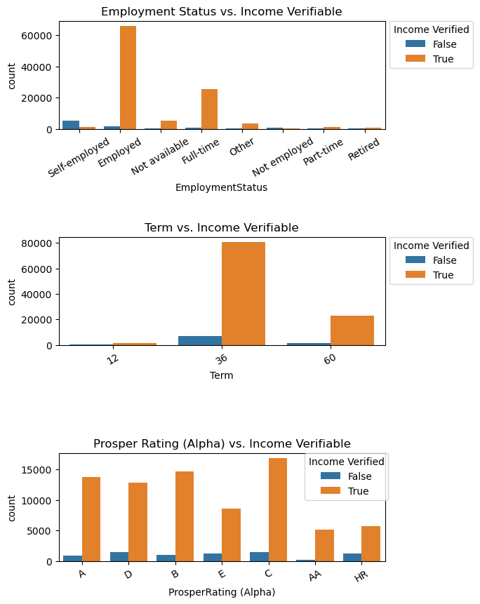

```python
plt.figure(figsize = [6, 10])

#subplot 1
plt.subplot(3,1,1)
sns.countplot(data = subset, x = 'EmploymentStatus', hue = 'IncomeVerifiable')
plt.legend(bbox_to_anchor=(1.27, 1),
           borderaxespad=0, title = "Income Verified")
plt.xticks(rotation = 30)
plt.title('Employment Status vs. Income Verifiable');

#subplot 2
plt.subplot(3,1,2)
sns.countplot(data = subset, x = 'Term', hue = 'IncomeVerifiable')
plt.legend(bbox_to_anchor=(1.27, 1),
           borderaxespad=0, title = "Income Verified")
plt.xticks(rotation = 30)
plt.title('Term vs. Income Verifiable');

#subplot 3
plt.subplot(3,1,3)
sns.countplot(data = subset, x = 'ProsperRating (Alpha)', hue = 'IncomeVerifiable')
plt.legend(bbox_to_anchor=(1.01, 1),
           borderaxespad=0, title = "Income Verified")
plt.xticks(rotation = 30)
plt.title('Prosper Rating (Alpha) vs. Income Verifiable');

plt.subplots_adjust(hspace=1)
```

I have decided to explore the relationship between the 'IncomeVerified' column against other variables. Starting at the top and similair to the last exploration with employment status, there isn't enough data to show the interactions of 'part-time', 'not employed' and 'retired'. However, we can see that across the others that a majority of loans were given to those whose income were verfied. 'Self-employed' doesn't follow this; it seems that most loans in this category isn't verified.

Moving on to the next plot, that a majority of the loans are verfied and mostly seperated into 2 different terms: 36-month and 60-month, the former took the lion share.

This is a little surprising since the distribution shows a perfect bell-curve when examining verified income. The count is near the lowest for the worst rating 'HR', then steady increases up before hitting the highest count at rating 'C'. Then it begins to taper before hitting the lowest point at the best rating 'AA'. The distribution for unverified income isn't the same, however. From the worst rating, it remained about the same, tapering a little bit as the rating increases, but took a massive hit at the best rating.

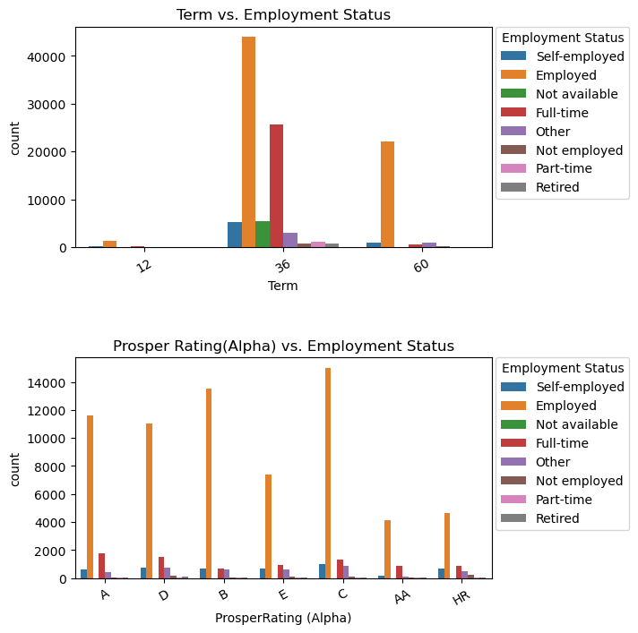

```python
plt.figure(figsize = [6, 8])

#subplot 1
plt.subplot(2,1,1)
sns.countplot(data = subset, x = 'Term', hue = 'EmploymentStatus')
plt.legend(bbox_to_anchor=(1.01, 1),
           borderaxespad=0, title = "Employment Status")
plt.xticks(rotation = 30)
plt.title('Term vs. Employment Status');

#subplot 2
plt.subplot(2,1,2)
sns.countplot(data = subset, x = 'ProsperRating (Alpha)', hue = 'EmploymentStatus')
plt.legend(bbox_to_anchor=(1.01, 1),
           borderaxespad=0, title = "Employment Status")
plt.xticks(rotation = 30)
plt.title('Prosper Rating(Alpha) vs. Employment Status');

plt.subplots_adjust(hspace=.5)
```

Next, I have decided to explore the relationship between the 'EmploymentStatus' column against other variables. From the top distribution, we see that employed holds the most loans overall. Most of them are 36-month loans and 60 months. However, one interesting thing to note is the high the count for full-timmers taking out 36-month loans.

In the next graph, we see the employed has the highest count across all ratings, followed by full-time. It is also intersting to note that the distribution for employed seems to be normally distributed.

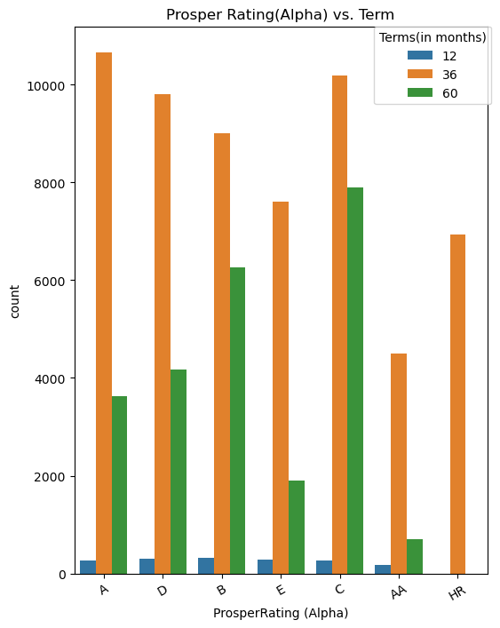

```python
plt.figure(figsize = [6, 8])

#subplot 1
sns.countplot(data = subset, x = 'ProsperRating (Alpha)', hue = 'Term')
plt.legend(bbox_to_anchor=(1.01, 1),
           borderaxespad=0, title = 'Terms(in months)')
plt.xticks(rotation = 30)
plt.title('Prosper Rating(Alpha) vs. Term');
```

Lastly, I have decided to explore the last combination of relationships between the 'Term' column against ProsperRating (Alpha). As we know, there wasn't many 12-month loans to begin with. We see that it has been evenly distributed among all rating, except HR. Furthermore, the HR rating doesn't even have a single 60-month loan either.

Before moving on to my bivariate analysis, I want to examine the relationship between the APR with two other numeric variables: 'LoanOriginalAmount' and 'DebtToIncomeRatio'. Instead of a heatmap, I will be examining it with scatterplots.

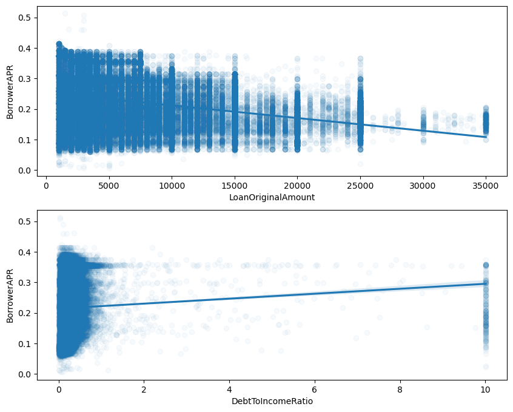

```python
plt.figure(figsize = [10, 8])

plt.subplot(2,1,1)
sns.regplot(data = subset, x = 'LoanOriginalAmount', y = 'BorrowerAPR', scatter_kws={'alpha': 1/30});

plt.subplot(2,1,2)
sns.regplot(data = subset, x = 'DebtToIncomeRatio', y = 'BorrowerAPR', scatter_kws={'alpha': 1/30});
```

### Talk about some of the relationships you observed in this part of the investigation. How did the feature(s) of interest vary with other features in the dataset?

From the heatmap we conduct at the beginning, we found that the correlation coefficient between the loan amount and APRis -0.32, making moderate negative relationship. The higher the loan, the lower the APR. This can be seen on the first scatterplot that has been plotted.

### Did you observe any interesting relationships between the other features (not the main feature(s) of interest)?

The relationship between Debt-to-Income Ratio and Stated Monthly Income is also negatively correlated.Something else we can make out is that the correlation between the original loan amount and stated monthly income is 0.20, meaning that it's positively correlated. This makes sense since the higher the income, the higher the loan you should be able to acquire. Furthermore, an interesting reationship between the rating and term. First, we see that there are only 36-month loans given to the 'HR' rating, the lowest one while other ratings have a healthy mix of all 3 terms.

### Multivariate Exploration

```python
num_var = ['BorrowerAPR', 'StatedMonthlyIncome', 'LoanOriginalAmount', 'DebtToIncomeRatio']
cat_var = ['LoanStatus', 'IncomeVerifiable', 'EmploymentStatus', 'Term', 'ProsperRating (Alpha)']
```

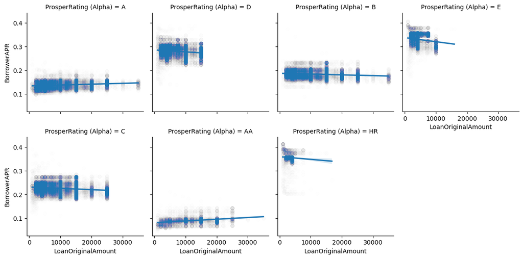

```python
g = sns.FacetGrid(data = subset, col = 'ProsperRating (Alpha)', col_wrap = 4)
g.map(sns.regplot,'LoanOriginalAmount', 'BorrowerAPR', x_jitter = 0.05, scatter_kws = {'alpha': 0.005});
```

It seems that an individual's rating has some effect on the relationship between the original loan amount and APR. We can see the relationship gradually turn positive and get stronger as the rating increases.

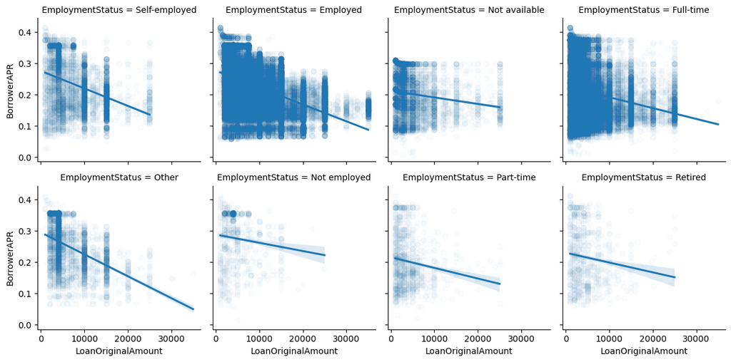

```python
g = sns.FacetGrid(data = subset, col = 'EmploymentStatus', col_wrap = 4)
g.map(sns.regplot,'LoanOriginalAmount', 'BorrowerAPR', x_jitter = 0.05, scatter_kws = {'alpha': 0.02});
```

I would like to how a loan's term would affect APR across the different ratings. to do this, I will be creating a boxplot

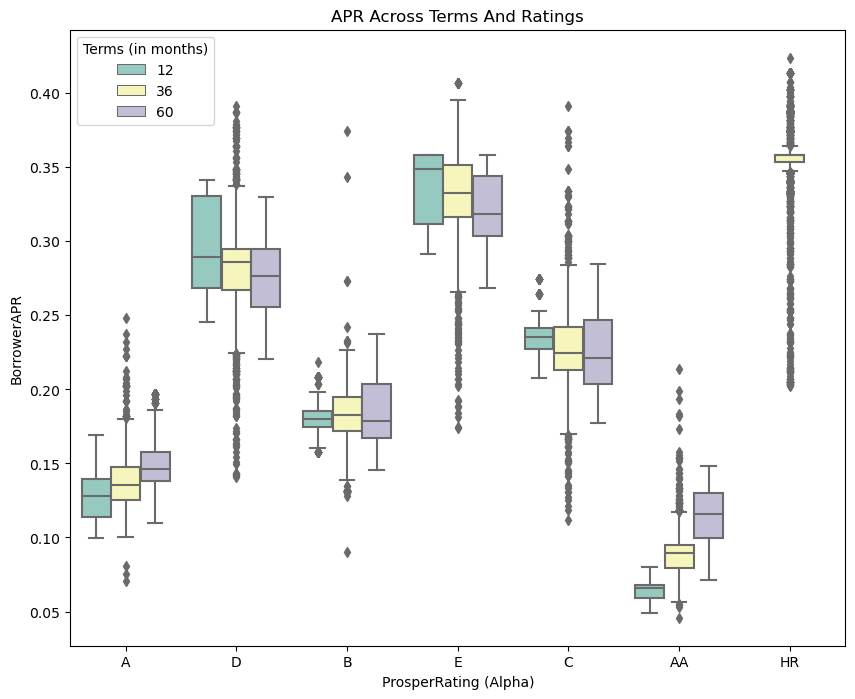

```python
fig = plt.figure(figsize = [10, 8])
ax = sns.boxplot(x='ProsperRating (Alpha)', y='BorrowerAPR', hue='Term',
                 data=subset, palette="Set3")
plt.title('APR Across Terms And Ratings')
plt.legend(title = 'Terms (in months)');
```

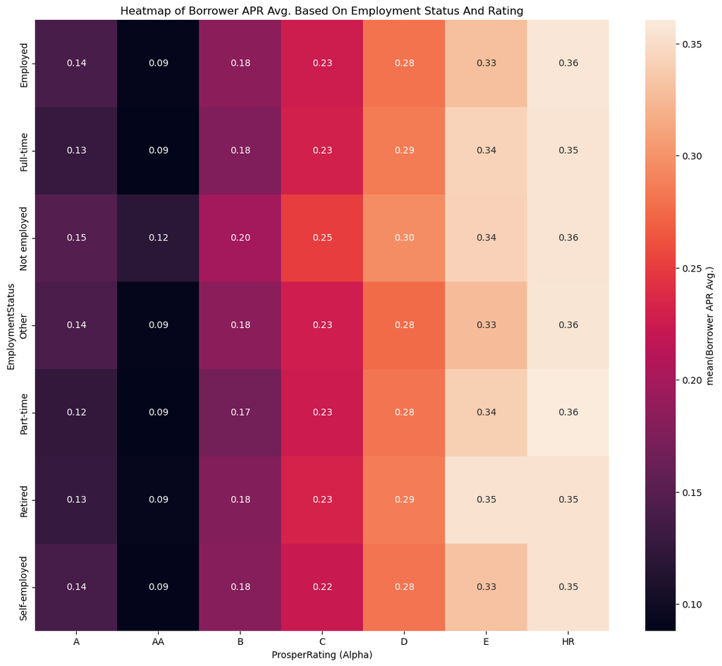

```python
c_means = subset.groupby(['ProsperRating (Alpha)', 'EmploymentStatus']).mean()['BorrowerAPR']
c_means = c_means.reset_index(name = 'Borrower APR Avg.')
c_means = c_means.pivot(index = 'EmploymentStatus', columns = 'ProsperRating (Alpha)',
                       values = 'Borrower APR Avg.')
sns.heatmap(c_means, annot = True, fmt = '.2f', cbar_kws = {'label': 'mean(Borrower APR Avg.)'})
plt.title('Heatmap of Borrower APR Avg. Based On Employment Status And Rating');
```

## Conclusions

Three major questions guided the entire exploration and analysis of the loan dataset which are: